# **3D MRI Hippocampus Segmentation (Case Study)**

This case study demonstrates a **lightweight, reproducible 2D U-Net** for segmenting the **anterior** and **posterior** hippocampus from **T1-weighted 3D MRI**.  
The hippocampus is a key biomarker in **Alzheimer’s disease** and **temporal lobe epilepsy**, but manual delineation is time-consuming and requires expert input.  
Here, a **single-baseline pipeline** is shown that can be run end-to-end on modest hardware.

### **Project motivation**

Automated hippocampus segmentation must handle **class imbalance**, **bias-field artefacts**, and **anatomical variability** under limited data and compute.  
This pipeline focuses on:

- **N4 bias-field correction** and **ROI-aware cropping** for robust pre-processing
- **Class imbalance** mitigation via slice-level oversampling + loss weighting
- An efficient **MobileNetV3-Small encoder** within a 2D U-Net backbone

> This notebook trains **one baseline model** (U-Net + MobileNetV3-Small encoder).  
> Other architectures were explored separately but are not included here to keep the run reproducible and concise.

### **Notebook roadmap**

1. **Pre-processing:** MRI correction, normalisation, cropping, augmentation
2. **Model:** 2D U-Net + MobileNetV3 encoder, Dice + weighted CE loss
3. **Training:** fixed baseline configuration with deterministic seeding
4. **Evaluation:** 3D Dice/IoU, confusion matrix, qualitative overlays

> All figures and metrics are generated directly from code for full reproducibility.

Environment Versions

| Package | Version |
| --- | --- |
| Python | 3.12.12 |
| PyTorch | 2.8.0+cu126 |
| Torchvision | 0.23.0+cu126 |
| segmentation-models-pytorch | 0.5.0 |
| nibabel | 5.3.2 |
| pandas | 2.2.2 |

## **Dataset description**

Paired **3D T1 MRI volumes** and hippocampus masks are provided (classes: Background = 0, Anterior = 1, Posterior = 2).  
Training and test partitions are separate; all volumes are resampled to isotropic spacing and stored as `.nii.gz`.

[output not shown]

Training is **slice-wise**; metrics are later aggregated back to **3D** per subject.

### **Dataset shape summary**

Volume / Slice Shape Summary

| Height | Width | Slices |
| --- | --- | --- |
| 31 | 40 | 24 |
| 35 | 50 | 35 |
| 42 | 59 | 47 |

### **Slice counts per volume**

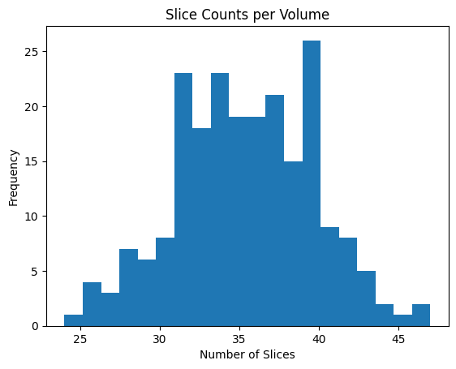

### **Hippocampus ROI % per slice**

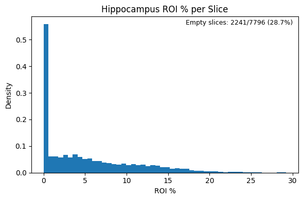

### **Representative slices at different ROI levels**

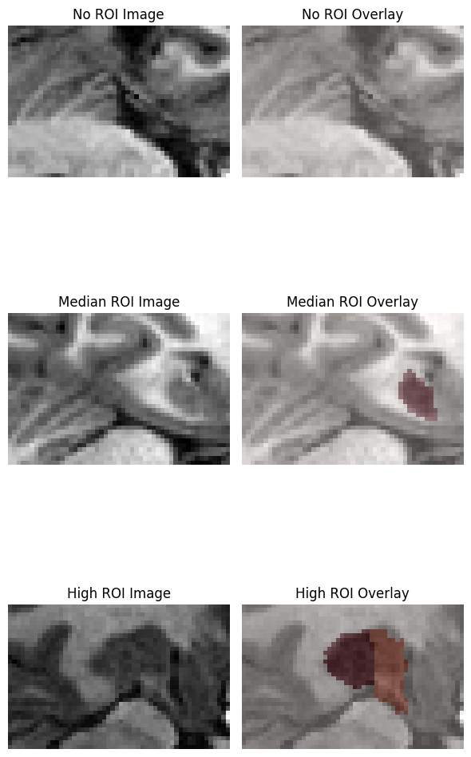

## **Pre-processing pipeline**

Each volume passes through reproducible steps that reduce artefacts, standardise intensity, and centre on the hippocampus:

1. **N4 bias-field correction** – corrects coil inhomogeneity using *SimpleITK N4*.
2. **Z-score normalisation** $$ I'=\frac{I-\mu}{\sigma+10^{-8}} $$ for intensity consistency.
3. **ROI-aware cropping** – crops around the maximal hippocampus bounding box + margin.
4. **2D slice extraction + augmentation**
   - horizontal flip
   - small rotations (±10°)
   - mild intensity jitter
5. **Reproducibility controls**
   - All randomness seeded (`SEED = 42`, including DataLoader workers).
   - Optional `DETERMINISTIC` flag for bit-exact reruns.

Preprocessing Parameters

| Crop size | Margin (voxels) |
| --- | --- |
| 79 | 10 |

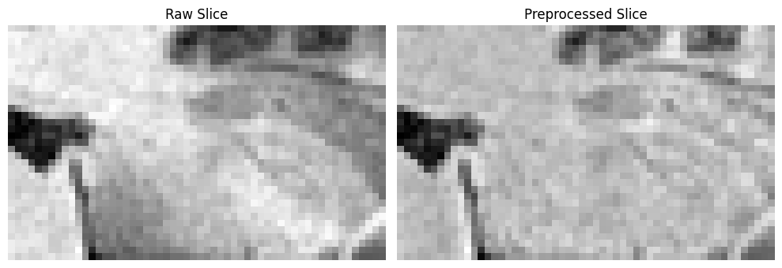

## **Model overview**

To perform voxel-wise segmentation of the hippocampus, a **2D U-Net** architecture was implemented using the [`segmentation_models_pytorch`](https://github.com/qubvel/segmentation_models.pytorch) (SMP) library.  
Each slice from the 3D MRI volume is treated as an independent training sample, allowing the model to learn spatial and intensity features in a memory-efficient manner.

### **Why 2D instead of 3D?**

Although 3D CNNs can exploit inter-slice context, their computational cost is high relative to the dataset size. A 2D U-Net provides a better trade-off between:

- **Generalisation:** fewer parameters, less overfitting on limited data
- **Speed:** faster training and inference, compatible with modest GPUs
- **Compatibility:** easy integration with slice-level augmentation and oversampling

## **Architecture design**

| Component | Configuration | Purpose |
| --- | --- | --- |
| **Encoder** | *MobileNetV3-Small* (ImageNet-pretrained) | Efficient feature extraction via depthwise separable convolutions |
| **Decoder** | Standard U-Net upsampling blocks | Gradual recovery of spatial detail |
| **Input channels** | 1 (grayscale MRI slices) | Adapts to single-modality imaging |
| **Output classes** | 3 | Background (0), Anterior (1), Posterior (2) |
| **Activation** | Softmax | Produces per-class probability maps |
| **Total parameters** | ≈8.2 M | Lightweight, deployable on edge devices |

The encoder’s pretrained weights accelerate convergence and stabilise training.  
The decoder mirrors the encoder depth with skip connections, restoring fine-grained anatomical boundaries.

## **Loss formulation**

Segmentation performance was optimised using a **hybrid loss function** combining:

$$ \mathcal{L}=\mathcal{L}_{\text{CE}}+\mathcal{L}_{\text{Dice}} $$

where:

- **Cross-Entropy (CE)** penalises voxel-wise classification errors and incorporates **class weights** to counter the dominance of background pixels.
- **Dice Loss** encourages spatial overlap between predicted and true masks, improving boundary delineation in small regions such as the hippocampus.

This combination ensures stable gradients while maintaining sensitivity to small, irregular ROIs.

## **Optimisation & regularisation**

> *The model architecture and training design were selected to achieve strong segmentation accuracy under constrained computational resources, reflecting typical healthcare ML deployment conditions.*

Cross-Entropy Class Weights

| Class | Weight |
| --- | --- |
| Background | 0.1229 |
| Anterior | 4.2748 |
| Posterior | 4.6023 |

## **Cross-validation and hyperparameter tuning**

Given the limited dataset size, robust model selection was achieved using **K-Fold cross-validation**  
(( K = 5 ) for full runs; ( K = 2 ) under TEST mode for quick checks).  
This approach ensures that every subject contributes to both training and validation splits, providing a more reliable estimate of model generalisation compared to a single hold-out set.

For each configuration of hyperparameters $(\text{lr},\ \text{batch size},\ \text{weight decay})$, the model was trained on ( K-1 ) folds and validated on the remaining one. The configuration with the highest mean validation performance was then retained.

[output not shown]

The full search is skipped in TEST mode to conserve compute time, ensuring the pipeline can be rapidly validated end-to-end before committing to a longer training run.

## **Addressing class imbalance**

1. **Slice-level oversampling:**
   - Slices containing ROI (anterior/posterior hippocampus) were sampled more frequently  
     using a `WeightedRandomSampler`.
   - Ensures that each mini-batch contains informative slices, improving gradient signal.
2. **Voxel-level loss weighting:**
   - The **Cross-Entropy** component of the loss used class weights inversely proportional to class frequency.
   - Misclassifying hippocampal voxels incurs a higher penalty, improving sensitivity to small regions.

Together, these methods stabilised training and yielded more balanced predictions across classes.

## **Reproducibility controls**

To ensure experimental rigour and facilitate reproducibility:

- All sources of randomness (Python, NumPy, PyTorch, DataLoader workers) were seeded with a global **`SEED = 42`**.
- A **`DETERMINISTIC`** flag allows toggling between speed (non-deterministic) and exact reproducibility modes.
- Cross-validation folds, parameter sampling, and samplers all use fixed random states.

> *These measures guarantee that identical conditions produce identical results—critical for scientific transparency and reliable model comparison.*

## **Training regime**

The best-performing configuration was then re-trained on the full training set and saved for final evaluation on the held-out test set.

Data Split

| Train volumes | Held-out volumes |
| --- | --- |
| 198 | 22 |

Cross-Validation Summary

| Folds (K) | Trials | Max epochs | weight_decay | lr | batch_size | Best CV score |
| --- | --- | --- | --- | --- | --- | --- |
| 5 | 10 | 50 | 0.00010 | 0.00100 | 4 | -0.4289 |

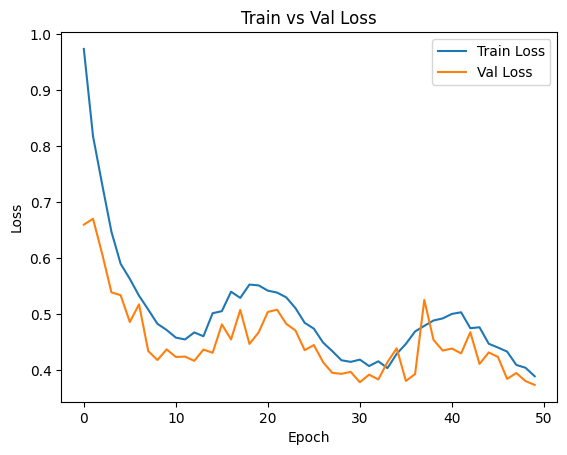

## **Evaluation methodology**

Model evaluation was conducted on a **held-out test set** comprising unseen MRI volumes and their corresponding ground-truth hippocampus masks.  
Each 3D test volume was pre-processed using the same N4 bias correction and z-score normalisation steps as in training to ensure consistent intensity scaling.

The trained model performs **slice-wise inference**, predicting a class label (background, anterior, posterior) for each pixel in every 2D slice.  
Predicted slices are then **re-assembled into full 3D volumes**, from which segmentation metrics are computed.

## **Quantitative metrics**

Performance was quantified using standard overlap measures:

$$ \text{Dice}=\frac{2\,TP}{2\,TP+FP+FN}, \qquad \text{IoU}=\frac{TP}{TP+FP+FN} $$

where (TP), (FP), and (FN) are voxel counts aggregated over the 3D mask.

For each subject volume, Dice and IoU were computed independently, and mean ± standard-deviation values summarised performance across the cohort.

| Metric | Description | Ideal Value |
| --- | --- | --- |
| Dice coefficient | Measures volumetric overlap | 1.0 |
| IoU | Intersection-over-Union between predicted and true masks | 1.0 |

## **Qualitative assessment**

To complement quantitative scores, predictions were visualised through:

1. **Confusion matrix** — normalised across classes to reveal tendencies in misclassification between anterior and posterior regions.
2. **Overlay plots** — superimposing predicted masks on MRI slices to qualitatively assess anatomical plausibility.
3. **Best vs Worst case visualisations** — middle slices from the volumes with the highest and lowest Dice scores.

These visual diagnostics help verify that errors are localised and clinically interpretable, rather than random across the volume.

Test Set Metrics

| Metric | Value |
| --- | --- |
| 3D Dice (mean ± sd) | 0.7262 ± 0.0376 |
| 3D IoU (mean ± sd) | 0.5715 ± 0.0460 |

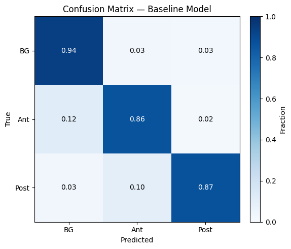

## **Key results**

[output not shown]

## **Summary of findings**

> *These outcomes demonstrate that a lightweight, slice-based U-Net can produce clinically meaningful hippocampal segmentations suitable for scalable neuroimaging workflows.*

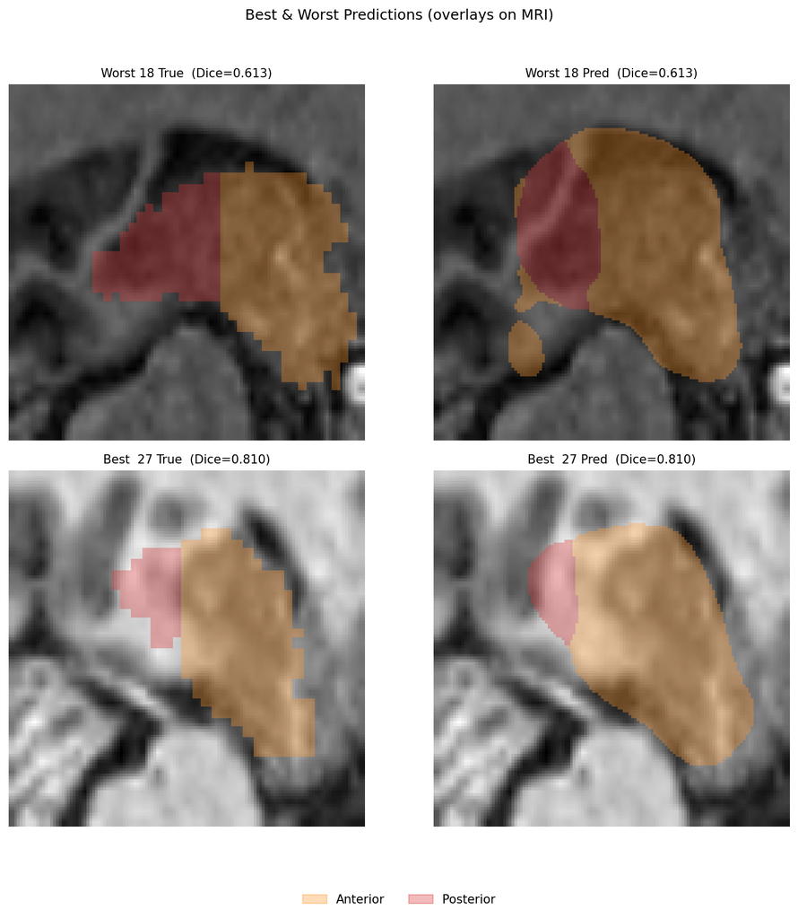

## **Discussion**

The use of **N4 bias correction**, **ROI-driven cropping**, and **z-score normalisation** proved essential for improving intensity uniformity and localising relevant tissue. Moreover, the combined **Dice + weighted Cross-Entropy loss** successfully balanced foreground–background disparity, while oversampling ensured that hippocampal slices contributed proportionally to gradient updates.

## **Limitations**

- **Dataset size and diversity:**  
  The dataset was relatively small and homogeneous. Larger, multi-centre data could improve robustness to scanner differences and anatomical variability.
- **2D processing:**  
  Slice-based training ignores inter-slice spatial context, which may limit continuity across volume boundaries. 3D or hybrid 2.5D architectures could recover this context.
- **Single-modality input:**  
  Only T1-weighted images were used; incorporating T2 or FLAIR sequences could enhance boundary delineation, especially in pathological cases.
- **No post-processing:**  
  Morphological filtering or conditional random fields could further smooth predictions and remove small false positives.

## **Future work**

1. **Extend to 3D or attention-based U-Nets** to capture spatial dependencies without sacrificing efficiency.
2. **Integrate multi-modal MRI** to leverage complementary contrast information.
3. **Apply transfer learning** from larger neuroimaging datasets (e.g., ADNI).
4. **Quantify uncertainty** in predictions for clinical interpretability.
5. **Benchmark against 3D baselines** and evaluate generalisation on unseen scanners.

> *Ultimately, this project demonstrates how thoughtful engineering—through reproducible data handling, balanced training, and efficient architectures—can yield reliable medical AI models even in data-constrained environments.*

### **Acknowledgements**

This notebook forms the computational companion to the **Advanced Machine Learning in Healthcare (CHME0035)** module at **UCL**, and was developed as part of the author’s MSc Health Data Science coursework.